# Midterm Presentation

# Count of Admission Type by Age2

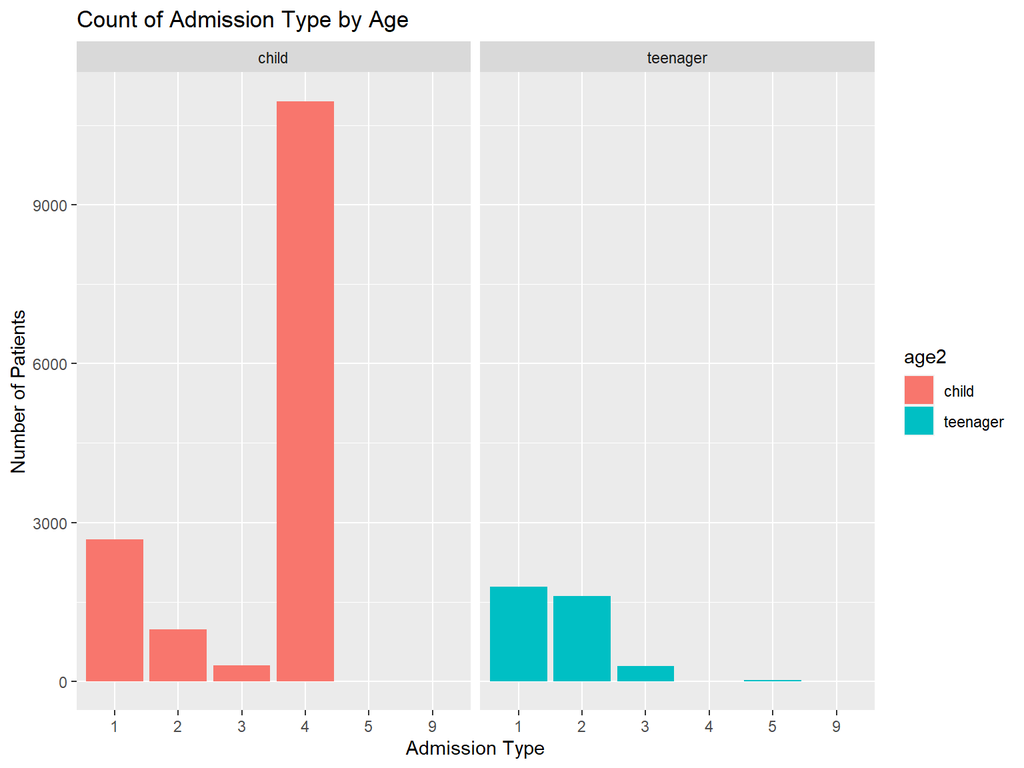

**Count of Admission Type by Age(Not Adult)**

- Now, both child and teenager results resemble that of an adult.
- The exception is the large amount of admission type 4 (newborn) for child.

# Average Length of Stay by Age

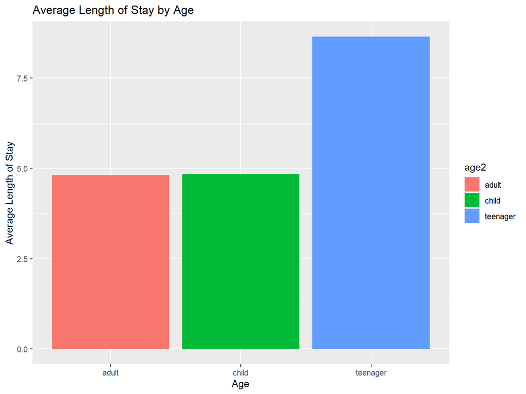

**Average Length of Stay by Age**

- For child and adult, the average length of stay is about 5 days.
- For teenager, the average length of stay is about 9 days.
- This could explain why teenager costs were so much higher, on average.